# Impares

2025-01-31

```r
#Agregar el dataset
movies <- read.csv('movies.csv', stringsAsFactors = FALSE)
```

## 2 Tipos de variable

ID: es una variable cualitativa nominal, pues sirve para identificar cada película

Popularity: es una variable cuantitativa medible continua pues es una cantdad que puede medirse en base a ciertos criterios.

Budget: es una variable cuantitativa contable pues representa una cantidad de dinero.

Revenue: es una variable cuantitativa contable ya que representa una cantidad de dinero.

“Original title: es una variable cualitativa nominal ya que sirve para identificar el nombre de cada película.”

Original language: es una variable cualitativa nominal ya que sirve para indicar en que lenguaje se hizo la película originalmente.

Title: es una variable cualitativa nominal y sirve para indicar cuál es el título en inglés de la película

Home page: es una variable cualitativa nominal y sirve para indicar si la película tiene un sitio web.

Video: es una variable cualitativa nominal, pues sirve para idnciar si la película tiene promocionales o no.

Director: es una variable cualitativa nominal la cua´l indica el nombre del director de la película.

Runtime: es una variable cuantitativa continua medible, pues sirve para indicar el tiempo de duración de la película el cuál puede ser perfectamente medido con aparatos como un temporizador o cronómetro.

Genres: es una variable cualitativa nominal pues sirve para identificar los géneros de la película.

Genres amount: es una variable cuantitativa discreta pues indica la cantidad de géneros a los que pertence cada película.

Production company: es una variale cualitativa nominal la cual indica la compañía que produjo la película.

Production company amount: es una variable cuantitativa discreta que indica la cantidad de compañías involucradas en la producción de la película.

Production company country: es una variable cualitativa nominal pues sirve para indicar que países estuvieron involucrados en la producción de la película.

Production countries amount: es una variable cuantitativa discreta la cuál indica la cantidadde países involucrados en la producción de la película.

Release date: es una variable cuantitativa nominal pues indica la fecha de lanzamiento de la película. A pesar de ser numeral no es cuantitativa pues no puede contarse.

Vote count: es una variable cuantitativa discreta pues indica la cantidad de gente que reseñó la película.”

Actors: es una variable cualitativa nominal la cuál indica el nombre de los actores involucrados en la película.

“Actors popularity: es una variable cuantitatva discreta la cuál sirve panra indicar, en números decimales, que tan poular es un actor.”

Actor Character: es una variable cualitativa nominal pues sirve para indicar el nombre del personaje que interpreta cada actor en la película.

Actors amount: es una variable cuantitativa discreta pues indica la cantidad de actores que están involucrados en la película.

Cast women amount: es una variable cuantitativa discreta la cuál indica la cantidad de actrices que participaron en la película.

Cast men amount: es una variable cuantitativa discreta que indica la canidad de actores que participaron el la película.

## 4.2 Películas que más ingresos generaron

```r
top10movies <- head(movies[order(movies$revenue, decreasing = TRUE), c("originalTitle", "revenue")], 10)

top10movies
```

```
##                     originalTitle    revenue
## 3211                       Avatar 2847246203
## 5953            Avengers: Endgame 2797800564
## 308                       Titanic 2187463944
## 4948 Star Wars: The Force Awakens 2068223624
## 5954       Avengers: Infinity War 2046239637
## 4915               Jurassic World 1671713208
## 7135                The Lion King 1667635327
## 9050      Spider-Man: No Way Home 1631853496
## 3398                 The Avengers 1518815515
## 5088                    Furious 7 1515047671
```

Se puede observar que la película que más ingresos ha generado es Avatar mientras que el puesto 10 lo ocupa Furious 7. Otro dato interesante es que hay 3 películas de Avengers en el top 10.

## 4.4 Peor película de acuerdo a los votos de los usuarios

```r
worstmovie <- head(movies[order(movies$voteCount, decreasing = FALSE), c("originalTitle", "voteCount")], 1)

worstmovie
```

```
##              originalTitle voteCount
## 4794 La Mera Reyna del Sur         1
```

## 4.6.1 Género principal de las 20 películas más recientes

```r
genres <- head(movies[order(movies$releaseDate, decreasing = TRUE), c("genres", "originalTitle")], 20)



genres_splitted <- strsplit(genres$genres, split = "|", fixed = TRUE)

genre_table <- table(unlist(genres_splitted))

most_popular_genre = names(genre_table)[which.max(genre_table)]

times_poula_genre = max(genre_table)

genres
```

```
##                                  genres
## 9517                              Drama
## 9546                       Comedy|Drama
## 9198                      Drama|Mystery
## 9587        Action|Thriller|Crime|Drama
## 9809                           Thriller
## 9952                       Action|Drama
## 9983                        Documentary
## 9242
## 9258
## 9867                            Romance
## 9684 Animation|Adventure|Fantasy|Family
## 9878            Horror|Thriller|Mystery
## 9989                             Comedy
## 9347             Comedy|Romance|Fantasy
```

[output cut: 27 more lines]

El género principal es las 20 películas más recientes es el de Comedy, este está presente en 7 películas

## 4.6.2 Género más popular en general

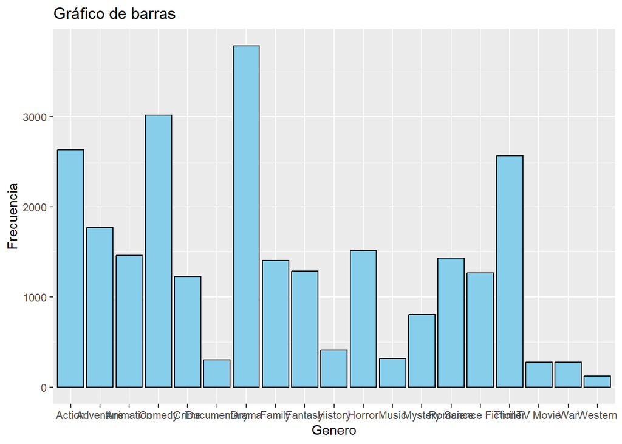

```r
library(ggplot2)

all_genres <- movies[, "genres"]

all_genres_splitted <- strsplit(all_genres, split = "|", fixed = TRUE)


table_genres <- table(unlist(all_genres_splitted))

genres_df <- as.data.frame(table_genres)

colnames(genres_df) <- c("Genero", "Frecuencia")


ggplot(genres_df, aes(x = Genero, y = Frecuencia)) +
  geom_bar(stat = "identity", fill = "skyblue", color = "black") +
  labs(title = "Gráfico de barras",
       x = "Genero",
       y = "Frecuencia")
```

Se puede observar que el drama es el género más popular.

## 4.6.3 Género de las películas más largas

```r
quantile_test <- quantile(movies[, "runtime"], 0.75)



largest_movies_genres <- movies[movies$runtime > quantile_test, "genres" ]

largest_movies_genres_splitted <- strsplit(largest_movies_genres, split = "|", fixed = TRUE)

new_table <- table(unlist(largest_movies_genres_splitted))

new_table
```

```
##
##          Action       Adventure       Animation          Comedy           Crime
##             792             525              82             404             425
##     Documentary           Drama          Family         Fantasy         History
##              44            1451              99             277             271
##          Horror           Music         Mystery         Romance Science Fiction
##             141              80             205             423             309
##        Thriller        TV Movie             War         Western
##             695              17             172              64
```

El género predominante en las películas más largas es el de Drama

## 4.8.1 ¿La cantidad de actores influye en el éxito de las películas?

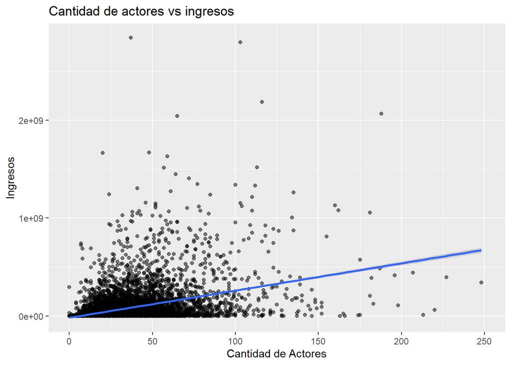

```r
library(ggplot2)




ggplot(movies, aes(x = actorsAmount, y = revenue)) +
  geom_point(alpha = 0.5) +
  geom_smooth(method = "lm") +
  labs(title = "Cantidad de actores vs ingresos",
       x = "Cantidad de Actores",
       y = "Ingresos") +
  xlim(0, 250)
```

```r
library(dplyr)
```

[figure not shown]

```r
movies$releaseYear <- substr(movies$releaseDate, 1, 4)

movies_years <- movies[, c("actorsAmount", "releaseYear")]

movies_grouped <- movies_years %>%
  group_by(releaseYear) %>%
  summarise(avg_actors = mean(actorsAmount, na.rm = TRUE))

ggplot(movies_grouped, aes(x = as.numeric(releaseYear), y = avg_actors)) +
  geom_line(color = "blue") +
  labs(title = "Number of Movies Released Per Year",
       x = "Year",
       y = "Number of Movies") +
  theme_minimal()
```

El gráfico muestra que a partir de la década de los 2000 ha habido un incremento en el promedio de actores involucrados en del desarrollo de una película, sin embargo hay un notorio bajón en el año 2022, esto podría deberse a que en el dataset no se tiene registro de las películas más populares de ese año.

```r
best_rated_movies = movies[ order(movies$voteAvg != " ", decreasing = TRUE), c("director", "originalTitle")]

head(best_rated_movies, 20)
```

```
##                                                                director
## 1  Allison Anders|Alexandre Rockwell|Robert Rodriguez|Quentin Tarantino
## 2                                                       Stephen Hopkins
## 3                                                          George Lucas
## 4                                                        Andrew Stanton
## 5                                                       Robert Zemeckis
## 6                                                            Sam Mendes
## 7                                                          Orson Welles
## 8                                                        Lars von Trier
## 9                                                            Luc Besson
## 10                                                           Fritz Lang
## 11                                                       Gore Verbinski
## 12                                                    Quentin Tarantino
## 13                                                           Sam Mendes
## 14                                                 Michael Winterbottom
```

[output cut: 27 more lines]

## 4.12 ¿Se asocian ciertos meses de lanzamiento con mejores ingresos?

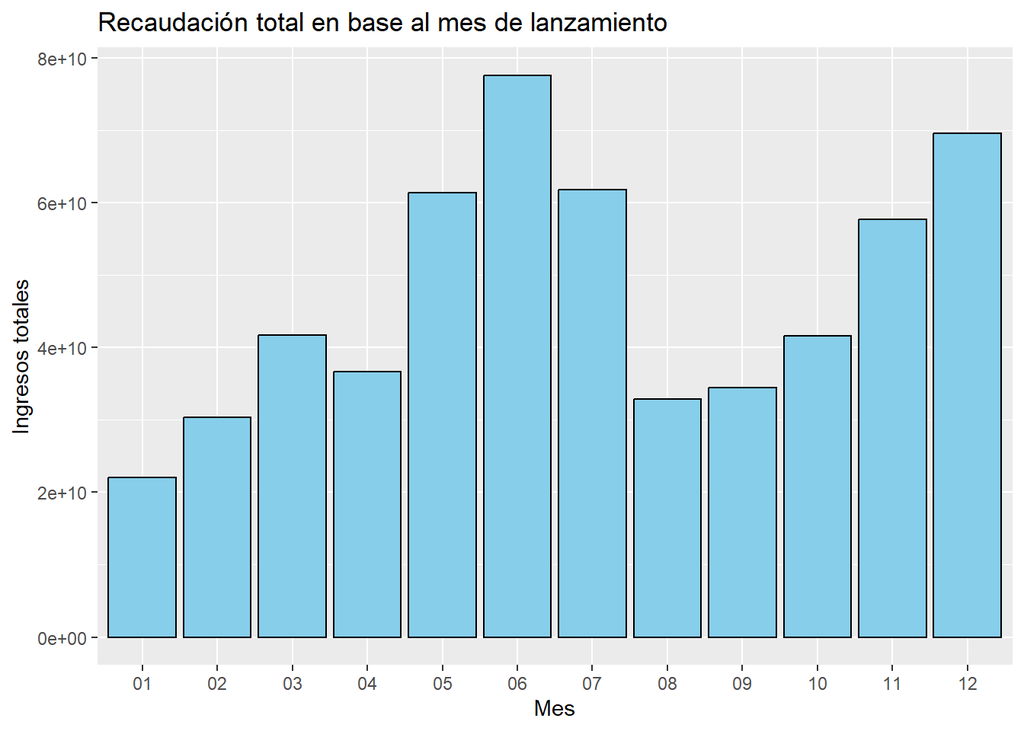

```r
movies$releaseMonth <- substr(movies$releaseDate, 6, 7)

movies_months <- movies[, c("revenue", "releaseMonth")]

movies_grouped_month <- movies_months %>%
  group_by(releaseMonth) %>%
  summarise(total_revenue = sum(revenue, na.rm = TRUE))

ggplot(movies_grouped_month, aes(x = releaseMonth, y = total_revenue)) +
  geom_bar(stat = "identity", fill = "skyblue", color = "black") +
  labs(title = "Recaudación total en base al mes de lanzamiento",
       x = "Mes",
       y = "Ingresos totales")
```

El gráfico muestra que en los meses de junio y diciembre se han obtenido más ganancias que en otros meses, esto puede deberse a que en varios países hay vacaciones de verano durante junio, mientras que en diciembre se celebran las fiestas y para algunas familias es una tradición ir al cine en estas fechas.

## 4.14